# Analyzing The Value of Point Guards During The 2020-2021 NBA Season and How It Has Changed Over The Years

[figure not shown]

Project by: Ryan Leeson, Hamid Nassehi, Matarr Cham

**Introduction**

The point guard is one of five positions playable on a basketball team. During a game, the point guard is considered an extension of the coach on the court. They lead the team while setting up plays and understanding the tempo of the game. The point guard is often considered the most important position in basketball. A good point guard is often defined by the “assists” statistic and their ability to score. They also need to be good defensively to disrupt the opposing point guard. The game of basketball is evolving, today’s athletes are more versatile. They blur the lines, players like Lebron James often play multiple roles while on the court. The era of one-dimensional players has ended, Is the role of a point guard still relevant in today’s game. Our group seeks to answer that question. We are analyzing the 2020-2021 NBA season player statistics with the intention of observing how the point guard influences the success of a team.

**Motivation**

Our motivation comes from our love for basketball and the interest in the sport, as well as analytics. We really wanted to observe and analyze to see if point guards actually effect the winning percentage of a team. Before this project, we thought that point guards have a large impact on teams but we had to analyze and make sure that this was correct.

**Hypothesis**

The era of one-dimensional players has ended, is the role of a point guard still relevant in today’s game? Based off our knowledge about basketball and the sport today. We believe that point guards are one of, if not the most valuable position in basketball. This hypothesis of ours is based upon the recent transition in the sport of basketball in the past 10 years that focuses much more on scoring, offense and three pointers which point guards lead this change as they tend to handle the ball the most and lead their team's offense.

**Data Scraping**

To begin, we scraped the data, using HTTP requests, from https://www.basketball-reference.com/leagues/NBA_2021_standings.html. The Beautiful Soup library was used to clean up the data as well as extract the necessary tables. The table we chose shows the stats of all players that played during the 2020-2021 season. We included another table the shows a teams' overall win percentage for the season. We will be using this data to get a better understanding of point guard's performances and how the teams they played for were impacted by their performances.

```python
#Importing
import requests
import numpy as np
import lxml.html as lh
import pandas as pd
from bs4 import BeautifulSoup
import matplotlib.pyplot as plt
import seaborn as sns
```

```python
# Scarping data from the website - this dataset is strictly for player stats
URL = "https://www.basketball-reference.com/leagues/NBA_2021_per_game.html"
page = requests.get(URL)
soup = BeautifulSoup(page.content, 'html.parser')
data = soup.prettify()

#Finding the table
table = soup.find('table')
first_table = pd.read_html(str(table))[0]

#Dropping the the first column
first_table = first_table.drop('Rk',1)
first_table
```

|  | Player | Pos | Age | Tm | G | GS | MP | FG | FGA | FG% | 3P | 3PA | 3P% | 2P | 2PA | 2P% | eFG% | FT | FTA | FT% | ORB | DRB | TRB | AST | STL | BLK | TOV | PF | PTS |
| --- | --- | --- | --- | --- | --- | --- | --- | --- | --- | --- | --- | --- | --- | --- | --- | --- | --- | --- | --- | --- | --- | --- | --- | --- | --- | --- | --- | --- | --- |
| 0 | Precious Achiuwa | PF | 21 | MIA | 61 | 4 | 12.1 | 2.0 | 3.7 | .544 | 0.0 | 0.0 | .000 | 2.0 | 3.7 | .546 | .544 | 0.9 | 1.8 | .509 | 1.2 | 2.2 | 3.4 | 0.5 | 0.3 | 0.5 | 0.7 | 1.5 | 5.0 |
| 1 | Jaylen Adams | PG | 24 | MIL | 7 | 0 | 2.6 | 0.1 | 1.1 | .125 | 0.0 | 0.3 | .000 | 0.1 | 0.9 | .167 | .125 | 0.0 | 0.0 | NaN | 0.0 | 0.4 | 0.4 | 0.3 | 0.0 | 0.0 | 0.0 | 0.1 | 0.3 |
| 2 | Steven Adams | C | 27 | NOP | 58 | 58 | 27.7 | 3.3 | 5.3 | .614 | 0.0 | 0.1 | .000 | 3.3 | 5.3 | .620 | .614 | 1.0 | 2.3 | .444 | 3.7 | 5.2 | 8.9 | 1.9 | 0.9 | 0.7 | 1.3 | 1.9 | 7.6 |
| 3 | Bam Adebayo | C | 23 | MIA | 64 | 64 | 33.5 | 7.1 | 12.5 | .570 | 0.0 | 0.1 | .250 | 7.1 | 12.4 | .573 | .571 | 4.4 | 5.5 | .799 | 2.2 | 6.7 | 9.0 | 5.4 | 1.2 | 1.0 | 2.6 | 2.3 | 18.7 |
| 4 | LaMarcus Aldridge | C | 35 | TOT | 26 | 23 | 25.9 | 5.4 | 11.4 | .473 | 1.2 | 3.1 | .388 | 4.2 | 8.3 | .505 | .525 | 1.6 | 1.8 | .872 | 0.7 | 3.8 | 4.5 | 1.9 | 0.4 | 1.1 | 1.0 | 1.8 | 13.5 |
| ... | ... | ... | ... | ... | ... | ... | ... | ... | ... | ... | ... | ... | ... | ... | ... | ... | ... | ... | ... | ... | ... | ... | ... | ... | ... | ... | ... | ... | ... |
| 726 | Delon Wright | PG | 28 | SAC | 27 | 8 | 25.8 | 3.9 | 8.3 | .462 | 1.2 | 3.1 | .398 | 2.6 | 5.3 | .500 | .536 | 1.1 | 1.3 | .833 | 1.0 | 2.9 | 3.9 | 3.6 | 1.6 | 0.4 | 1.3 | 1.1 | 10.0 |
| 727 | Thaddeus Young | PF | 32 | CHI | 68 | 23 | 24.3 | 5.4 | 9.7 | .559 | 0.2 | 0.7 | .267 | 5.3 | 9.1 | .580 | .568 | 1.0 | 1.7 | .628 | 2.5 | 3.8 | 6.2 | 4.3 | 1.1 | 0.6 | 2.0 | 2.2 | 12.1 |
| 728 | Trae Young | PG | 22 | ATL | 63 | 63 | 33.7 | 7.7 | 17.7 | .438 | 2.2 | 6.3 | .343 | 5.6 | 11.3 | .491 | .499 | 7.7 | 8.7 | .886 | 0.6 | 3.3 | 3.9 | 9.4 | 0.8 | 0.2 | 4.1 | 1.8 | 25.3 |
| 729 | Cody Zeller | C | 28 | CHO | 48 | 21 | 20.9 | 3.8 | 6.8 | .559 | 0.1 | 0.6 | .143 | 3.7 | 6.2 | .598 | .565 | 1.8 | 2.5 | .714 | 2.5 | 4.4 | 6.8 | 1.8 | 0.6 | 0.4 | 1.1 | 2.5 | 9.4 |
| 730 | Ivica Zubac | C | 23 | LAC | 72 | 33 | 22.3 | 3.6 | 5.5 | .652 | 0.0 | 0.1 | .250 | 3.6 | 5.4 | .656 | .654 | 1.9 | 2.4 | .789 | 2.6 | 4.6 | 7.2 | 1.3 | 0.3 | 0.9 | 1.1 | 2.6 | 9.0 |

731 rows × 29 columns

```python
# Scarping data from the website - this dataset is stricly for team stats
URL = "https://www.proballers.com/basketball/league/3/nba/standings/2020"
page = requests.get(URL)
soup = BeautifulSoup(page.content, 'html.parser')
data = soup.prettify()

#finding the table
table = soup.find('table')
second_table = pd.read_html(str(table))[0]

#Dropping the 1st column
second_table = second_table.drop('Rank',1)
second_table
```

|  | Team | % Victory | Gp | Gw | GL | Pts+ | Pts- | Ga |
| --- | --- | --- | --- | --- | --- | --- | --- | --- |
| 0 | Utah Jazz | 72.22 | 72 | 52 | 20 | 8382 | 7716 | 1.0863 |
| 1 | Phoenix Suns | 70.83 | 72 | 51 | 21 | 8300 | 7881 | 1.0531 |
| 2 | Philadelphia 76ers | 68.06 | 72 | 49 | 23 | 8182 | 7780 | 1.0516 |
| 3 | Brooklyn Nets | 66.67 | 72 | 48 | 24 | 8537 | 8213 | 1.0394 |
| 4 | LA Clippers | 65.28 | 72 | 47 | 25 | 8209 | 7764 | 1.0573 |
| 5 | Denver Nuggets | 65.28 | 72 | 47 | 25 | 8284 | 7929 | 1.0447 |
| 6 | Milwaukee Bucks | 63.89 | 72 | 46 | 26 | 8649 | 8225 | 1.0515 |
| 7 | Los Angeles Lakers | 58.33 | 72 | 42 | 30 | 7887 | 7686 | 1.0261 |
| 8 | Dallas Mavericks | 58.33 | 72 | 42 | 30 | 8094 | 7933 | 1.0202 |
| 9 | Portland Trail Blazers | 58.33 | 72 | 42 | 30 | 8360 | 8231 | 1.0156 |
| 10 | New York Knicks | 56.94 | 72 | 41 | 31 | 7706 | 7540 | 1.0220 |
| 11 | Atlanta Hawks | 56.94 | 72 | 41 | 31 | 8186 | 8019 | 1.0208 |
| 12 | Miami Heat | 55.56 | 72 | 40 | 32 | 7781 | 7779 | 1.0002 |
| 13 | Golden State Warriors | 54.17 | 72 | 39 | 33 | 8187 | 8111 | 1.0093 |
| 14 | Memphis Grizzlies | 52.11 | 71 | 37 | 34 | 8035 | 7970 | 1.0081 |
| 15 | Boston Celtics | 50.00 | 72 | 36 | 36 | 8109 | 8004 | 1.0131 |
| 16 | Washington Wizards | 47.89 | 71 | 34 | 37 | 8297 | 8409 | 0.9866 |
| 17 | Indiana Pacers | 47.22 | 72 | 34 | 38 | 8302 | 8303 | 0.9998 |
| 18 | Charlotte Hornets | 45.83 | 72 | 33 | 39 | 7881 | 8020 | 0.9826 |
| 19 | San Antonio Spurs | 45.07 | 71 | 32 | 39 | 7877 | 8022 | 0.9819 |
| 20 | New Orleans Pelicans | 43.66 | 71 | 31 | 40 | 8139 | 8149 | 0.9987 |
| 21 | Sacramento Kings | 43.06 | 72 | 31 | 41 | 8189 | 8454 | 0.9686 |
| 22 | Chicago Bulls | 42.25 | 71 | 30 | 41 | 7864 | 7931 | 0.9915 |
| 23 | Toronto Raptors | 38.03 | 71 | 27 | 44 | 7906 | 7916 | 0.9987 |
| 24 | Minnesota Timberwolves | 31.94 | 72 | 23 | 49 | 8073 | 8473 | 0.9527 |
| 25 | Oklahoma City Thunder | 30.99 | 71 | 22 | 49 | 7447 | 8204 | 0.9077 |
| 26 | Cleveland Cavaliers | 30.56 | 72 | 22 | 50 | 7476 | 8084 | 0.9247 |
| 27 | Orlando Magic | 29.17 | 72 | 21 | 51 | 7488 | 8158 | 0.9178 |
| 28 | Detroit Pistons | 26.09 | 69 | 18 | 51 | 7322 | 7676 | 0.9538 |
| 29 | Houston Rockets | 23.61 | 72 | 17 | 55 | 7833 | 8402 | 0.9322 |

In this part, we acquire data that will be used to compare our 2020-2021 data with 1999-2000 data. We have scraped the needed information that we need for this part. This was a vital part of the project since we needed to compare the data that was gained in 2020-2021 to another set of data to see how the role of point guards has changed throughout time.

```python
# Scarping data from the website - this dataset is strictly for player stats
URL = "https://www.basketball-reference.com/leagues/NBA_2000_per_game.html"
page = requests.get(URL)
soup = BeautifulSoup(page.content, 'html.parser')
data = soup.prettify()

#Finding the table
table = soup.find('table')
retro_table = pd.read_html(str(table))[0]

#Dropping the the first column
retro_table = retro_table.drop('Rk',1)
retro_table

count = 0
lst = []
for st in retro_table['GS']:
    if st == "GS":
        retro_table = retro_table.drop(count)
    if st != "GS":
        lst.append(int(st))
    count += 1
retro_table["gs"] = lst

#Restricting the data to games played more than 40, 26 out of 29 teams, DAL TOR LAC
retro_table = retro_table[retro_table["gs"] >= 40]

#Restricting the data to only PG
retro_table = retro_table[retro_table["Pos"] == "PG"]
retro_table

retro_table = retro_table.rename(columns={'Tm': 'Team'})
# Scarping data from the website - this dataset is stricly for team stats
URL = "https://www.proballers.com/basketball/league/3/nba/standings/1999"
page = requests.get(URL)
soup = BeautifulSoup(page.content, 'html.parser')
data = soup.prettify()

#finding the table
table = soup.find('table')
retrosecond_table = pd.read_html(str(table))[0]

#Dropping the 1st column
retrosecond_table = retrosecond_table.drop('Rank',1)
retrosecond_table
#We use retro_table to compare the performance points in 1999 - 2000 for the next part
```

|  | Team | % Victory | Gp | Gw | GL | Pts+ | Pts- | Ga |
| --- | --- | --- | --- | --- | --- | --- | --- | --- |
| 0 | Los Angeles Lakers | 81.71 | 82 | 67 | 15 | 8267 | 7566 | 1.0926 |
| 1 | Portland Trail Blazers | 71.95 | 82 | 59 | 23 | 7991 | 7466 | 1.0703 |
| 2 | Indiana Pacers | 68.29 | 82 | 56 | 26 | 8306 | 7929 | 1.0475 |
| 3 | Utah Jazz | 67.07 | 82 | 55 | 27 | 7914 | 7548 | 1.0484 |
| 4 | San Antonio Spurs | 64.63 | 82 | 53 | 29 | 7886 | 7399 | 1.0658 |
| 5 | Phoenix Suns | 64.63 | 82 | 53 | 29 | 8111 | 7683 | 1.0557 |
| 6 | Miami Heat | 63.41 | 82 | 52 | 30 | 7739 | 7484 | 1.0340 |
| 7 | Minnesota Timberwolves | 60.98 | 82 | 50 | 32 | 8079 | 7872 | 1.0262 |
| 8 | New York Knicks | 60.98 | 82 | 50 | 32 | 7555 | 7435 | 1.0161 |
| 9 | Charlotte Hornets | 59.76 | 82 | 49 | 33 | 8072 | 7853 | 1.0278 |
| 10 | Philadelphia 76ers | 59.76 | 82 | 49 | 33 | 7771 | 7661 | 1.0143 |
| 11 | Seattle SuperSonics | 54.88 | 82 | 45 | 37 | 8125 | 8047 | 1.0096 |
| 12 | Toronto Raptors | 54.88 | 82 | 45 | 37 | 7968 | 7981 | 0.9983 |
| 13 | Sacramento Kings | 53.66 | 82 | 44 | 38 | 8607 | 8368 | 1.0285 |
| 14 | Detroit Pistons | 51.22 | 82 | 42 | 40 | 8483 | 8365 | 1.0141 |
| 15 | Milwaukee Bucks | 51.22 | 82 | 42 | 40 | 8300 | 8282 | 1.0021 |
| 16 | Orlando Magic | 50.00 | 82 | 41 | 41 | 8206 | 8150 | 1.0068 |
| 17 | Dallas Mavericks | 48.78 | 82 | 40 | 42 | 8316 | 8363 | 0.9943 |
| 18 | Boston Celtics | 42.68 | 82 | 35 | 47 | 8146 | 8208 | 0.9924 |
| 19 | Denver Nuggets | 42.68 | 82 | 35 | 47 | 8115 | 8289 | 0.9790 |
| 20 | Houston Rockets | 41.46 | 82 | 34 | 48 | 8156 | 8227 | 0.9913 |
| 21 | Cleveland Cavaliers | 39.02 | 82 | 32 | 50 | 7950 | 8237 | 0.9651 |
| 22 | Brooklyn Nets | 37.80 | 82 | 31 | 51 | 8036 | 8121 | 0.9895 |
| 23 | Washington Wizards | 35.37 | 82 | 29 | 53 | 7921 | 8190 | 0.9671 |
| 24 | Atlanta Hawks | 34.15 | 82 | 28 | 54 | 7735 | 8176 | 0.9460 |
| 25 | Memphis Grizzlies | 26.83 | 82 | 22 | 60 | 7702 | 8163 | 0.9435 |
| 26 | Golden State Warriors | 23.17 | 82 | 19 | 63 | 7834 | 8512 | 0.9203 |
| 27 | Chicago Bulls | 20.73 | 82 | 17 | 65 | 6952 | 7723 | 0.9001 |
| 28 | LA Clippers | 18.29 | 82 | 15 | 67 | 7546 | 8491 | 0.8887 |

**Data Tidying**

After scraping the table, we have a lot of information that we don’t need. The table shows all players, we only require information about point guards. To see how a point guard affects the teams performance we selected point guards that played at least 40 out of 72 games. If there is a case where a team has two point guards that started over 40+ games, the player with the most games started is used for the analysis. If a team did not have one point guard play more than 40 games we dropped those teams from the tables. Those point guards did not play enough to analyze there impact on the team, therefore are not relevant. After making the necessary changes to both tables (team win % table and player stats table), the two tables were merged to create the table that will be used for analysis.

```python
count = 0
lst = []
for st in first_table['GS']:
    if st == "GS":
        first_table = first_table.drop(count)
    if st != "GS":
        lst.append(int(st))
    count += 1
first_table["gs"] = lst

#Restricting the data to games played more than 40
first_table = first_table[first_table["gs"] >= 40]

#Restricting the data to only PG
first_table = first_table[first_table["Pos"] == "PG"]
#UTA and BOS both have 2 PGs that played 40+ games
#Dropped the PG that played less games for those teams, Kemba Walker: 43 games, and Mike Conley: 51 games
first_table = first_table[first_table.Player != "Kemba Walker"]
first_table = first_table[first_table.Player != "Mike Conley"]
first_table = first_table.rename(columns={'Tm': 'Team'})

first_table
```

|  | Player | Pos | Age | Team | G | GS | MP | FG | FGA | FG% | 3P | 3PA | 3P% | 2P | 2PA | 2P% | eFG% | FT | FTA | FT% | ORB | DRB | TRB | AST | STL | BLK | TOV | PF | PTS | … |
| --- | --- | --- | --- | --- | --- | --- | --- | --- | --- | --- | --- | --- | --- | --- | --- | --- | --- | --- | --- | --- | --- | --- | --- | --- | --- | --- | --- | --- | --- | --- |
| 35 | Lonzo Ball | PG | 23 | NOP | 55 | 55 | 31.8 | 5.3 | 12.7 | .414 | 3.1 | 8.3 | .378 | 2.1 | 4.5 | .482 | .537 | 0.9 | 1.2 | .781 | 0.6 | 4.2 | 4.8 | 5.7 | 1.5 | 0.6 | 2.2 | 1.9 | 14.6 | … |
| 92 | Malcolm Brogdon | PG | 28 | IND | 56 | 56 | 34.5 | 7.9 | 17.5 | .453 | 2.6 | 6.7 | .388 | 5.3 | 10.8 | .493 | .527 | 2.7 | 3.2 | .864 | 1.0 | 4.2 | 5.3 | 5.9 | 0.9 | 0.3 | 2.1 | 2.0 | 21.2 | … |
| 156 | Stephen Curry | PG | 32 | GSW | 63 | 63 | 34.2 | 10.4 | 21.7 | .482 | 5.3 | 12.7 | .421 | 5.1 | 9.0 | .569 | .605 | 5.7 | 6.3 | .916 | 0.5 | 5.0 | 5.5 | 5.8 | 1.2 | 0.1 | 3.4 | 1.9 | 32.0 | … |
| 177 | Luka Dončić | PG | 21 | DAL | 66 | 66 | 34.3 | 9.8 | 20.5 | .479 | 2.9 | 8.3 | .350 | 6.9 | 12.2 | .567 | .550 | 5.2 | 7.1 | .730 | 0.8 | 7.2 | 8.0 | 8.6 | 1.0 | 0.5 | 4.3 | 2.3 | 27.7 | … |
| 217 | De'Aaron Fox | PG | 23 | SAC | 58 | 58 | 35.1 | 9.1 | 19.1 | .477 | 1.8 | 5.5 | .322 | 7.3 | 13.6 | .539 | .523 | 5.2 | 7.2 | .719 | 0.6 | 2.9 | 3.5 | 7.2 | 1.5 | 0.5 | 3.0 | 2.9 | 25.2 | … |
| 228 | Darius Garland | PG | 21 | CLE | 54 | 50 | 33.1 | 6.7 | 14.9 | .451 | 1.9 | 4.9 | .395 | 4.8 | 9.9 | .479 | .517 | 2.1 | 2.4 | .848 | 0.4 | 2.0 | 2.4 | 6.1 | 1.2 | 0.1 | 3.0 | 2.0 | 17.4 | … |
| 244 | Devonte' Graham | PG | 25 | CHO | 55 | 44 | 30.2 | 4.6 | 12.2 | .377 | 3.3 | 8.7 | .375 | 1.3 | 3.5 | .380 | .510 | 2.4 | 2.9 | .842 | 0.4 | 2.3 | 2.7 | 5.4 | 0.9 | 0.1 | 1.5 | 1.4 | 14.8 | … |
| 305 | Jrue Holiday | PG | 30 | MIL | 59 | 56 | 32.3 | 7.0 | 13.9 | .503 | 1.9 | 4.8 | .392 | 5.1 | 9.2 | .561 | .570 | 1.8 | 2.3 | .787 | 1.2 | 3.3 | 4.5 | 6.1 | 1.6 | 0.6 | 2.2 | 1.7 | 17.7 | … |
| 329 | Kyrie Irving | PG | 28 | BRK | 54 | 54 | 34.9 | 10.2 | 20.1 | .506 | 2.8 | 7.0 | .402 | 7.4 | 13.1 | .561 | .576 | 3.7 | 4.0 | .922 | 1.0 | 3.8 | 4.8 | 6.0 | 1.4 | 0.7 | 2.4 | 2.6 | 26.9 | … |
| 341 | LeBron James | PG | 36 | LAL | 45 | 45 | 33.4 | 9.4 | 18.3 | .513 | 2.3 | 6.3 | .365 | 7.1 | 12.0 | .591 | .576 | 4.0 | 5.7 | .698 | 0.6 | 7.0 | 7.7 | 7.8 | 1.1 | 0.6 | 3.7 | 1.6 | 25.0 | … |
| 410 | Damian Lillard | PG | 30 | POR | 67 | 67 | 35.8 | 9.0 | 19.9 | .451 | 4.1 | 10.5 | .391 | 4.9 | 9.4 | .519 | .554 | 6.7 | 7.2 | .928 | 0.5 | 3.7 | 4.2 | 7.5 | 0.9 | 0.3 | 3.0 | 1.5 | 28.8 | … |
| 418 | Kyle Lowry | PG | 34 | TOR | 46 | 46 | 34.8 | 5.7 | 13.0 | .436 | 2.8 | 7.2 | .396 | 2.8 | 5.8 | .487 | .546 | 3.0 | 3.5 | .875 | 0.8 | 4.6 | 5.4 | 7.3 | 1.0 | 0.3 | 2.7 | 3.1 | 17.2 | … |
| 423 | Théo Maledon | PG | 19 | OKC | 65 | 49 | 27.4 | 3.5 | 9.4 | .368 | 1.6 | 4.8 | .335 | 1.9 | 4.6 | .402 | .454 | 1.6 | 2.1 | .748 | 0.4 | 2.9 | 3.2 | 3.5 | 0.9 | 0.2 | 2.2 | 1.9 | 10.1 | … |
| 470 | Donovan Mitchell | PG | 24 | UTA | 53 | 53 | 33.4 | 9.0 | 20.6 | .438 | 3.4 | 8.7 | .386 | 5.7 | 11.9 | .476 | .520 | 5.0 | 6.0 | .845 | 0.9 | 3.5 | 4.4 | 5.2 | 1.0 | 0.3 | 2.8 | 2.2 | 26.4 | … |
| 474 | Ja Morant | PG | 21 | MEM | 63 | 63 | 32.6 | 6.8 | 15.2 | .449 | 1.2 | 3.8 | .303 | 5.7 | 11.4 | .499 | .487 | 4.3 | 5.9 | .728 | 0.9 | 3.1 | 4.0 | 7.4 | 0.9 | 0.2 | 3.2 | 1.4 | 19.1 | … |
| 480 | Dejounte Murray | PG | 24 | SAS | 67 | 67 | 31.9 | 6.6 | 14.5 | .453 | 0.9 | 3.0 | .317 | 5.6 | 11.6 | .488 | .485 | 1.6 | 2.0 | .791 | 0.9 | 6.2 | 7.1 | 5.4 | 1.5 | 0.1 | 1.7 | 2.0 | 15.7 | … |
| 481 | Jamal Murray | PG | 23 | DEN | 48 | 48 | 35.5 | 7.9 | 16.5 | .477 | 2.7 | 6.6 | .408 | 5.2 | 9.9 | .523 | .559 | 2.8 | 3.2 | .869 | 0.8 | 3.3 | 4.0 | 4.8 | 1.3 | 0.3 | 2.3 | 2.0 | 21.2 | … |
| 496 | Kendrick Nunn | PG | 25 | MIA | 56 | 44 | 29.5 | 5.7 | 11.8 | .485 | 2.2 | 5.7 | .381 | 3.5 | 6.0 | .583 | .578 | 1.0 | 1.1 | .933 | 0.4 | 2.8 | 3.2 | 2.6 | 0.9 | 0.3 | 1.4 | 1.9 | 14.6 | … |
| 529 | Chris Paul | PG | 35 | PHO | 70 | 70 | 31.4 | 6.3 | 12.6 | .499 | 1.5 | 3.7 | .395 | 4.8 | 8.9 | .543 | .557 | 2.4 | 2.6 | .934 | 0.4 | 4.1 | 4.5 | 8.9 | 1.4 | 0.3 | 2.2 | 2.4 | 16.4 | … |
| 531 | Elfrid Payton | PG | 26 | NYK | 63 | 63 | 23.6 | 4.3 | 9.9 | .432 | 0.4 | 1.6 | .286 | 3.8 | 8.3 | .460 | .455 | 1.2 | 1.7 | .682 | 1.0 | 2.4 | 3.4 | 3.2 | 0.7 | 0.1 | 1.6 | 1.8 | 10.1 | … |
| 597 | Ricky Rubio | PG | 30 | MIN | 68 | 51 | 26.1 | 2.8 | 7.3 | .388 | 1.0 | 3.1 | .308 | 1.9 | 4.2 | .447 | .454 | 1.9 | 2.2 | .867 | 0.4 | 2.9 | 3.3 | 6.4 | 1.4 | 0.1 | 1.6 | 2.0 | 8.6 | … |
| 614 | Ben Simmons | PG | 24 | PHI | 58 | 58 | 32.4 | 5.6 | 10.1 | .557 | 0.1 | 0.2 | .300 | 5.6 | 9.9 | .562 | .560 | 3.0 | 4.9 | .613 | 1.6 | 5.6 | 7.2 | 6.9 | 1.6 | 0.6 | 3.0 | 2.9 | 14.3 | … |
| 619 | Marcus Smart | PG | 26 | BOS | 48 | 45 | 32.9 | 4.2 | 10.6 | .398 | 1.9 | 5.9 | .330 | 2.3 | 4.8 | .482 | .489 | 2.7 | 3.4 | .790 | 0.8 | 2.7 | 3.5 | 5.7 | 1.5 | 0.5 | 2.0 | 2.6 | 13.1 | … |
| 690 | John Wall | PG | 30 | HOU | 40 | 40 | 32.2 | 7.3 | 18.2 | .404 | 2.0 | 6.2 | .317 | 5.4 | 11.9 | .449 | .458 | 4.0 | 5.3 | .749 | 0.4 | 2.8 | 3.2 | 6.9 | 1.1 | 0.8 | 3.5 | 1.2 | 20.6 | … |
| 700 | Russell Westbrook | PG | 32 | WAS | 65 | 65 | 36.4 | 8.4 | 19.0 | .439 | 1.3 | 4.2 | .315 | 7.0 | 14.8 | .475 | .474 | 4.2 | 6.4 | .656 | 1.7 | 9.9 | 11.5 | 11.7 | 1.4 | 0.4 | 4.8 | 2.9 | 22.2 | … |
| 701 | Coby White | PG | 20 | CHI | 69 | 54 | 31.2 | 5.4 | 13.1 | .416 | 2.4 | 6.6 | .359 | 3.1 | 6.5 | .473 | .506 | 1.9 | 2.1 | .901 | 0.4 | 3.7 | 4.1 | 4.8 | 0.6 | 0.2 | 2.3 | 2.6 | 15.1 | … |
| 728 | Trae Young | PG | 22 | ATL | 63 | 63 | 33.7 | 7.7 | 17.7 | .438 | 2.2 | 6.3 | .343 | 5.6 | 11.3 | .491 | .499 | 7.7 | 8.7 | .886 | 0.6 | 3.3 | 3.9 | 9.4 | 0.8 | 0.2 | 4.1 | 1.8 | 25.3 | … |

```python
#LAC, ORL, DET don't have any PG that played 40+ games
#Therefore we removed the teams that did not have a qualifying PG
second_table = second_table[second_table.Team != "Orlando Magic"]
second_table = second_table[second_table.Team != "LA Clippers"]
second_table = second_table[second_table.Team != "Detroit Pistons"]

#Adding teams to specific columns - putting the data where the teams are
second_table.at[0,'Team']='UTA'
second_table.at[1,'Team']='PHO'
second_table.at[2,'Team']='PHI'
second_table.at[3,'Team']='BRK'
second_table.at[5,'Team']='DEN'
second_table.at[6,'Team']='MIL'
second_table.at[7,'Team']='LAL'
second_table.at[8,'Team']='DAL'
second_table.at[9,'Team']='POR'
second_table.at[10,'Team']='NYK'
second_table.at[11,'Team']='ATL'
second_table.at[12,'Team']='MIA'
second_table.at[13,'Team']='GSW'
second_table.at[14,'Team']='MEM'
second_table.at[15,'Team']='BOS'
second_table.at[16,'Team']='WAS'
second_table.at[17,'Team']='IND'
second_table.at[18,'Team']='CHO'
second_table.at[19,'Team']='SAS'
second_table.at[20,'Team']='NOP'
second_table.at[21,'Team']='SAC'
second_table.at[22,'Team']='CHI'
second_table.at[23,'Team']='TOR'
second_table.at[24,'Team']='MIN'
second_table.at[25,'Team']='OKC'
second_table.at[26,'Team']='CLE'
second_table.at[29,'Team']='HOU'

second_table
```

|  | Team | % Victory | Gp | Gw | GL | Pts+ | Pts- | Ga |
| --- | --- | --- | --- | --- | --- | --- | --- | --- |
| 0 | UTA | 72.22 | 72 | 52 | 20 | 8382 | 7716 | 1.0863 |
| 1 | PHO | 70.83 | 72 | 51 | 21 | 8300 | 7881 | 1.0531 |
| 2 | PHI | 68.06 | 72 | 49 | 23 | 8182 | 7780 | 1.0516 |
| 3 | BRK | 66.67 | 72 | 48 | 24 | 8537 | 8213 | 1.0394 |
| 5 | DEN | 65.28 | 72 | 47 | 25 | 8284 | 7929 | 1.0447 |
| 6 | MIL | 63.89 | 72 | 46 | 26 | 8649 | 8225 | 1.0515 |
| 7 | LAL | 58.33 | 72 | 42 | 30 | 7887 | 7686 | 1.0261 |
| 8 | DAL | 58.33 | 72 | 42 | 30 | 8094 | 7933 | 1.0202 |
| 9 | POR | 58.33 | 72 | 42 | 30 | 8360 | 8231 | 1.0156 |
| 10 | NYK | 56.94 | 72 | 41 | 31 | 7706 | 7540 | 1.0220 |
| 11 | ATL | 56.94 | 72 | 41 | 31 | 8186 | 8019 | 1.0208 |
| 12 | MIA | 55.56 | 72 | 40 | 32 | 7781 | 7779 | 1.0002 |
| 13 | GSW | 54.17 | 72 | 39 | 33 | 8187 | 8111 | 1.0093 |
| 14 | MEM | 52.11 | 71 | 37 | 34 | 8035 | 7970 | 1.0081 |
| 15 | BOS | 50.00 | 72 | 36 | 36 | 8109 | 8004 | 1.0131 |
| 16 | WAS | 47.89 | 71 | 34 | 37 | 8297 | 8409 | 0.9866 |
| 17 | IND | 47.22 | 72 | 34 | 38 | 8302 | 8303 | 0.9998 |
| 18 | CHO | 45.83 | 72 | 33 | 39 | 7881 | 8020 | 0.9826 |
| 19 | SAS | 45.07 | 71 | 32 | 39 | 7877 | 8022 | 0.9819 |
| 20 | NOP | 43.66 | 71 | 31 | 40 | 8139 | 8149 | 0.9987 |
| 21 | SAC | 43.06 | 72 | 31 | 41 | 8189 | 8454 | 0.9686 |
| 22 | CHI | 42.25 | 71 | 30 | 41 | 7864 | 7931 | 0.9915 |
| 23 | TOR | 38.03 | 71 | 27 | 44 | 7906 | 7916 | 0.9987 |
| 24 | MIN | 31.94 | 72 | 23 | 49 | 8073 | 8473 | 0.9527 |
| 25 | OKC | 30.99 | 71 | 22 | 49 | 7447 | 8204 | 0.9077 |
| 26 | CLE | 30.56 | 72 | 22 | 50 | 7476 | 8084 | 0.9247 |
| 29 | HOU | 23.61 | 72 | 17 | 55 | 7833 | 8402 | 0.9322 |

```python
#Merging the tables to create the third table
third_table = pd.merge(first_table, second_table, on="Team")

#Dropping the columns that we dont need
third_table = third_table.drop('Gp',1)
third_table = third_table.drop('Gw',1)
third_table = third_table.drop('GL',1)
third_table = third_table.drop('Pts+',1)
third_table = third_table.drop('Pts-',1)
third_table = third_table.drop('Ga',1)
third_table = third_table.rename(columns={'% Victory': 'Win%'})

#Generating the table that will be used for analyzing and other parts
third_table
```

|  | Player | Pos | Age | Team | G | GS | MP | FG | FGA | FG% | 3P | 3PA | 3P% | 2P | 2PA | 2P% | eFG% | FT | FTA | FT% | ORB | DRB | TRB | AST | STL | BLK | TOV | PF | PTS | … |
| --- | --- | --- | --- | --- | --- | --- | --- | --- | --- | --- | --- | --- | --- | --- | --- | --- | --- | --- | --- | --- | --- | --- | --- | --- | --- | --- | --- | --- | --- | --- |
| 0 | Lonzo Ball | PG | 23 | NOP | 55 | 55 | 31.8 | 5.3 | 12.7 | .414 | 3.1 | 8.3 | .378 | 2.1 | 4.5 | .482 | .537 | 0.9 | 1.2 | .781 | 0.6 | 4.2 | 4.8 | 5.7 | 1.5 | 0.6 | 2.2 | 1.9 | 14.6 | … |
| 1 | Malcolm Brogdon | PG | 28 | IND | 56 | 56 | 34.5 | 7.9 | 17.5 | .453 | 2.6 | 6.7 | .388 | 5.3 | 10.8 | .493 | .527 | 2.7 | 3.2 | .864 | 1.0 | 4.2 | 5.3 | 5.9 | 0.9 | 0.3 | 2.1 | 2.0 | 21.2 | … |
| 2 | Stephen Curry | PG | 32 | GSW | 63 | 63 | 34.2 | 10.4 | 21.7 | .482 | 5.3 | 12.7 | .421 | 5.1 | 9.0 | .569 | .605 | 5.7 | 6.3 | .916 | 0.5 | 5.0 | 5.5 | 5.8 | 1.2 | 0.1 | 3.4 | 1.9 | 32.0 | … |
| 3 | Luka Dončić | PG | 21 | DAL | 66 | 66 | 34.3 | 9.8 | 20.5 | .479 | 2.9 | 8.3 | .350 | 6.9 | 12.2 | .567 | .550 | 5.2 | 7.1 | .730 | 0.8 | 7.2 | 8.0 | 8.6 | 1.0 | 0.5 | 4.3 | 2.3 | 27.7 | … |
| 4 | De'Aaron Fox | PG | 23 | SAC | 58 | 58 | 35.1 | 9.1 | 19.1 | .477 | 1.8 | 5.5 | .322 | 7.3 | 13.6 | .539 | .523 | 5.2 | 7.2 | .719 | 0.6 | 2.9 | 3.5 | 7.2 | 1.5 | 0.5 | 3.0 | 2.9 | 25.2 | … |
| 5 | Darius Garland | PG | 21 | CLE | 54 | 50 | 33.1 | 6.7 | 14.9 | .451 | 1.9 | 4.9 | .395 | 4.8 | 9.9 | .479 | .517 | 2.1 | 2.4 | .848 | 0.4 | 2.0 | 2.4 | 6.1 | 1.2 | 0.1 | 3.0 | 2.0 | 17.4 | … |
| 6 | Devonte' Graham | PG | 25 | CHO | 55 | 44 | 30.2 | 4.6 | 12.2 | .377 | 3.3 | 8.7 | .375 | 1.3 | 3.5 | .380 | .510 | 2.4 | 2.9 | .842 | 0.4 | 2.3 | 2.7 | 5.4 | 0.9 | 0.1 | 1.5 | 1.4 | 14.8 | … |
| 7 | Jrue Holiday | PG | 30 | MIL | 59 | 56 | 32.3 | 7.0 | 13.9 | .503 | 1.9 | 4.8 | .392 | 5.1 | 9.2 | .561 | .570 | 1.8 | 2.3 | .787 | 1.2 | 3.3 | 4.5 | 6.1 | 1.6 | 0.6 | 2.2 | 1.7 | 17.7 | … |
| 8 | Kyrie Irving | PG | 28 | BRK | 54 | 54 | 34.9 | 10.2 | 20.1 | .506 | 2.8 | 7.0 | .402 | 7.4 | 13.1 | .561 | .576 | 3.7 | 4.0 | .922 | 1.0 | 3.8 | 4.8 | 6.0 | 1.4 | 0.7 | 2.4 | 2.6 | 26.9 | … |
| 9 | LeBron James | PG | 36 | LAL | 45 | 45 | 33.4 | 9.4 | 18.3 | .513 | 2.3 | 6.3 | .365 | 7.1 | 12.0 | .591 | .576 | 4.0 | 5.7 | .698 | 0.6 | 7.0 | 7.7 | 7.8 | 1.1 | 0.6 | 3.7 | 1.6 | 25.0 | … |
| 10 | Damian Lillard | PG | 30 | POR | 67 | 67 | 35.8 | 9.0 | 19.9 | .451 | 4.1 | 10.5 | .391 | 4.9 | 9.4 | .519 | .554 | 6.7 | 7.2 | .928 | 0.5 | 3.7 | 4.2 | 7.5 | 0.9 | 0.3 | 3.0 | 1.5 | 28.8 | … |
| 11 | Kyle Lowry | PG | 34 | TOR | 46 | 46 | 34.8 | 5.7 | 13.0 | .436 | 2.8 | 7.2 | .396 | 2.8 | 5.8 | .487 | .546 | 3.0 | 3.5 | .875 | 0.8 | 4.6 | 5.4 | 7.3 | 1.0 | 0.3 | 2.7 | 3.1 | 17.2 | … |
| 12 | Théo Maledon | PG | 19 | OKC | 65 | 49 | 27.4 | 3.5 | 9.4 | .368 | 1.6 | 4.8 | .335 | 1.9 | 4.6 | .402 | .454 | 1.6 | 2.1 | .748 | 0.4 | 2.9 | 3.2 | 3.5 | 0.9 | 0.2 | 2.2 | 1.9 | 10.1 | … |
| 13 | Donovan Mitchell | PG | 24 | UTA | 53 | 53 | 33.4 | 9.0 | 20.6 | .438 | 3.4 | 8.7 | .386 | 5.7 | 11.9 | .476 | .520 | 5.0 | 6.0 | .845 | 0.9 | 3.5 | 4.4 | 5.2 | 1.0 | 0.3 | 2.8 | 2.2 | 26.4 | … |
| 14 | Ja Morant | PG | 21 | MEM | 63 | 63 | 32.6 | 6.8 | 15.2 | .449 | 1.2 | 3.8 | .303 | 5.7 | 11.4 | .499 | .487 | 4.3 | 5.9 | .728 | 0.9 | 3.1 | 4.0 | 7.4 | 0.9 | 0.2 | 3.2 | 1.4 | 19.1 | … |
| 15 | Dejounte Murray | PG | 24 | SAS | 67 | 67 | 31.9 | 6.6 | 14.5 | .453 | 0.9 | 3.0 | .317 | 5.6 | 11.6 | .488 | .485 | 1.6 | 2.0 | .791 | 0.9 | 6.2 | 7.1 | 5.4 | 1.5 | 0.1 | 1.7 | 2.0 | 15.7 | … |
| 16 | Jamal Murray | PG | 23 | DEN | 48 | 48 | 35.5 | 7.9 | 16.5 | .477 | 2.7 | 6.6 | .408 | 5.2 | 9.9 | .523 | .559 | 2.8 | 3.2 | .869 | 0.8 | 3.3 | 4.0 | 4.8 | 1.3 | 0.3 | 2.3 | 2.0 | 21.2 | … |
| 17 | Kendrick Nunn | PG | 25 | MIA | 56 | 44 | 29.5 | 5.7 | 11.8 | .485 | 2.2 | 5.7 | .381 | 3.5 | 6.0 | .583 | .578 | 1.0 | 1.1 | .933 | 0.4 | 2.8 | 3.2 | 2.6 | 0.9 | 0.3 | 1.4 | 1.9 | 14.6 | … |
| 18 | Chris Paul | PG | 35 | PHO | 70 | 70 | 31.4 | 6.3 | 12.6 | .499 | 1.5 | 3.7 | .395 | 4.8 | 8.9 | .543 | .557 | 2.4 | 2.6 | .934 | 0.4 | 4.1 | 4.5 | 8.9 | 1.4 | 0.3 | 2.2 | 2.4 | 16.4 | … |
| 19 | Elfrid Payton | PG | 26 | NYK | 63 | 63 | 23.6 | 4.3 | 9.9 | .432 | 0.4 | 1.6 | .286 | 3.8 | 8.3 | .460 | .455 | 1.2 | 1.7 | .682 | 1.0 | 2.4 | 3.4 | 3.2 | 0.7 | 0.1 | 1.6 | 1.8 | 10.1 | … |
| 20 | Ricky Rubio | PG | 30 | MIN | 68 | 51 | 26.1 | 2.8 | 7.3 | .388 | 1.0 | 3.1 | .308 | 1.9 | 4.2 | .447 | .454 | 1.9 | 2.2 | .867 | 0.4 | 2.9 | 3.3 | 6.4 | 1.4 | 0.1 | 1.6 | 2.0 | 8.6 | … |
| 21 | Ben Simmons | PG | 24 | PHI | 58 | 58 | 32.4 | 5.6 | 10.1 | .557 | 0.1 | 0.2 | .300 | 5.6 | 9.9 | .562 | .560 | 3.0 | 4.9 | .613 | 1.6 | 5.6 | 7.2 | 6.9 | 1.6 | 0.6 | 3.0 | 2.9 | 14.3 | … |
| 22 | Marcus Smart | PG | 26 | BOS | 48 | 45 | 32.9 | 4.2 | 10.6 | .398 | 1.9 | 5.9 | .330 | 2.3 | 4.8 | .482 | .489 | 2.7 | 3.4 | .790 | 0.8 | 2.7 | 3.5 | 5.7 | 1.5 | 0.5 | 2.0 | 2.6 | 13.1 | … |
| 23 | John Wall | PG | 30 | HOU | 40 | 40 | 32.2 | 7.3 | 18.2 | .404 | 2.0 | 6.2 | .317 | 5.4 | 11.9 | .449 | .458 | 4.0 | 5.3 | .749 | 0.4 | 2.8 | 3.2 | 6.9 | 1.1 | 0.8 | 3.5 | 1.2 | 20.6 | … |
| 24 | Russell Westbrook | PG | 32 | WAS | 65 | 65 | 36.4 | 8.4 | 19.0 | .439 | 1.3 | 4.2 | .315 | 7.0 | 14.8 | .475 | .474 | 4.2 | 6.4 | .656 | 1.7 | 9.9 | 11.5 | 11.7 | 1.4 | 0.4 | 4.8 | 2.9 | 22.2 | … |
| 25 | Coby White | PG | 20 | CHI | 69 | 54 | 31.2 | 5.4 | 13.1 | .416 | 2.4 | 6.6 | .359 | 3.1 | 6.5 | .473 | .506 | 1.9 | 2.1 | .901 | 0.4 | 3.7 | 4.1 | 4.8 | 0.6 | 0.2 | 2.3 | 2.6 | 15.1 | … |
| 26 | Trae Young | PG | 22 | ATL | 63 | 63 | 33.7 | 7.7 | 17.7 | .438 | 2.2 | 6.3 | .343 | 5.6 | 11.3 | .491 | .499 | 7.7 | 8.7 | .886 | 0.6 | 3.3 | 3.9 | 9.4 | 0.8 | 0.2 | 4.1 | 1.8 | 25.3 | … |

We used retro_table to monitor our 1999-2000 data set. We organized the information by teams and merged the needed tables together to be able to correctly visualize them.

```python
#Converting to float so we can use the needed variables - using retro_table. We use this table for specifically the 1999 - 2000 stats.
retrosecond_table = retrosecond_table[retrosecond_table.Team != "Dallas Mavericks"]
retrosecond_table = retrosecond_table[retrosecond_table.Team != "LA Clippers"]
retrosecond_table = retrosecond_table[retrosecond_table.Team != "Toronto Raptors"]

#Organizing the graph
retrosecond_table.at[0,'Team']='LAL'
retrosecond_table.at[1,'Team']='POR'
retrosecond_table.at[2,'Team']='IND'
retrosecond_table.at[3,'Team']='UTA'
retrosecond_table.at[4,'Team']='SAS'
retrosecond_table.at[5,'Team']='PHO'
retrosecond_table.at[6,'Team']='MIA'
retrosecond_table.at[7,'Team']='MIN'
retrosecond_table.at[8,'Team']='NYK'
retrosecond_table.at[9,'Team']='CHH'
retrosecond_table.at[10,'Team']='PHI'
retrosecond_table.at[11,'Team']='SEA'
retrosecond_table.at[13,'Team']='SAC'
retrosecond_table.at[14,'Team']='DET'
retrosecond_table.at[15,'Team']='MIL'
retrosecond_table.at[16,'Team']='ORL'
retrosecond_table.at[18,'Team']='BOS'
retrosecond_table.at[19,'Team']='DEN'
retrosecond_table.at[20,'Team']='HOU'
retrosecond_table.at[21,'Team']='CLE'
retrosecond_table.at[22,'Team']='NJN'
retrosecond_table.at[23,'Team']='WAS'
retrosecond_table.at[24,'Team']='ATL'
retrosecond_table.at[25,'Team']='VAN'
retrosecond_table.at[26,'Team']='GSW'
retrosecond_table.at[27,'Team']='CHI'


#Dropping the information that we do need from the graph
retro_table = pd.merge(retro_table, retrosecond_table, on="Team")
retro_table = retro_table.drop('Gp',1)
retro_table = retro_table.drop('Gw',1)
retro_table = retro_table.drop('GL',1)
retro_table = retro_table.drop('Pts+',1)
retro_table = retro_table.drop('Pts-',1)
retro_table = retro_table.drop('Ga',1)
retro_table = retro_table.rename(columns={'% Victory': 'Win%'})

retro_table['PTS'] = retro_table['PTS'].astype(float)
retro_table['AST'] = retro_table['AST'].astype(float)
retro_table['TRB'] = retro_table['TRB'].astype(float)
retro_table['DFS'] = retro_table['STL'].astype(float) + retro_table['BLK'].astype(float)
retro_table['eFG%'] = retro_table['eFG%'].astype(float)
retro_table['FT%'] = retro_table['FT%'].astype(float)

retro_table
```

|  | Player | Pos | Age | Team | G | GS | MP | FG | FGA | FG% | 3P | 3PA | 3P% | 2P | 2PA | 2P% | eFG% | FT | FTA | FT% | ORB | DRB | TRB | AST | STL | BLK | TOV | PF | PTS | … |
| --- | --- | --- | --- | --- | --- | --- | --- | --- | --- | --- | --- | --- | --- | --- | --- | --- | --- | --- | --- | --- | --- | --- | --- | --- | --- | --- | --- | --- | --- | --- |
| 0 | Kenny Anderson | PG | 29 | BOS | 82 | 82 | 31.6 | 5.3 | 12.0 | .440 | 1.0 | 2.7 | .386 | 4.3 | 9.3 | .456 | 0.483 | 2.4 | 3.1 | 0.775 | 0.7 | 2.1 | 2.7 | 5.1 | 1.7 | 0.1 | 1.6 | 2.8 | 14.0 | … |
| 1 | Darrell Armstrong | PG | 31 | ORL | 82 | 82 | 31.6 | 5.9 | 13.6 | .433 | 1.7 | 4.9 | .340 | 4.2 | 8.7 | .485 | 0.494 | 2.7 | 3.0 | 0.911 | 0.8 | 2.5 | 3.3 | 6.1 | 2.1 | 0.1 | 3.0 | 1.7 | 16.2 | … |
| 2 | Mike Bibby | PG | 21 | VAN | 82 | 82 | 38.5 | 5.6 | 12.6 | .445 | 0.9 | 2.6 | .363 | 4.7 | 10.0 | .466 | 0.483 | 2.4 | 3.0 | 0.780 | 0.9 | 2.8 | 3.7 | 8.1 | 1.6 | 0.2 | 3.0 | 2.1 | 14.5 | … |
| 3 | Mookie Blaylock | PG | 32 | GSW | 73 | 72 | 33.7 | 4.5 | 11.5 | .391 | 1.4 | 4.1 | .336 | 3.1 | 7.3 | .422 | 0.451 | 0.9 | 1.3 | 0.705 | 0.8 | 2.9 | 3.7 | 6.7 | 2.0 | 0.3 | 2.0 | 1.7 | 11.3 | … |
| 4 | Terrell Brandon | PG | 29 | MIN | 71 | 71 | 36.4 | 6.8 | 14.7 | .466 | 0.7 | 1.9 | .402 | 6.1 | 12.8 | .476 | 0.492 | 2.6 | 2.9 | 0.899 | 0.6 | 2.7 | 3.4 | 8.9 | 1.9 | 0.4 | 2.6 | 2.2 | 17.1 | … |
| 5 | Randy Brown | PG | 31 | CHI | 59 | 55 | 27.5 | 2.7 | 7.4 | .361 | 0.1 | 0.1 | .500 | 2.6 | 7.3 | .359 | 0.364 | 1.1 | 1.4 | 0.738 | 0.4 | 2.1 | 2.4 | 3.4 | 1.0 | 0.3 | 1.8 | 2.0 | 6.4 | … |
| 6 | Sam Cassell | PG | 30 | MIL | 81 | 81 | 35.8 | 6.7 | 14.4 | .466 | 0.3 | 1.1 | .289 | 6.4 | 13.3 | .481 | 0.477 | 4.8 | 5.5 | 0.876 | 0.9 | 2.9 | 3.7 | 9.0 | 1.3 | 0.1 | 3.3 | 3.1 | 18.6 | … |
| 7 | Bimbo Coles | PG | 31 | ATL | 80 | 54 | 24.1 | 3.5 | 7.6 | .455 | 0.1 | 0.5 | .205 | 3.4 | 7.1 | .472 | 0.461 | 1.1 | 1.3 | 0.817 | 0.4 | 1.8 | 2.2 | 3.6 | 0.7 | 0.1 | 1.3 | 2.2 | 8.1 | … |
| 8 | Steve Francis | PG | 22 | HOU | 77 | 77 | 36.1 | 6.5 | 14.5 | .445 | 1.4 | 4.0 | .345 | 5.1 | 10.5 | .483 | 0.493 | 3.7 | 4.7 | 0.786 | 2.0 | 3.3 | 5.3 | 6.6 | 1.5 | 0.4 | 4.0 | 3.0 | 18.0 | … |
| 9 | Tim Hardaway | PG | 33 | MIA | 52 | 52 | 32.2 | 4.7 | 12.3 | .386 | 1.8 | 4.9 | .367 | 2.9 | 7.3 | .398 | 0.459 | 2.1 | 2.6 | 0.827 | 0.5 | 2.4 | 2.9 | 7.4 | 0.9 | 0.1 | 2.3 | 2.2 | 13.4 | … |
| 10 | Ron Harper | PG | 36 | LAL | 80 | 78 | 25.5 | 2.7 | 6.6 | .399 | 0.4 | 1.3 | .311 | 2.2 | 5.3 | .421 | 0.430 | 1.3 | 1.8 | 0.680 | 1.2 | 3.0 | 4.2 | 3.4 | 1.1 | 0.5 | 1.7 | 2.1 | 7.0 | … |
| 11 | Lindsey Hunter | PG | 29 | DET | 82 | 82 | 35.6 | 4.6 | 10.9 | .425 | 2.0 | 4.7 | .432 | 2.6 | 6.1 | .419 | 0.519 | 1.4 | 1.9 | 0.760 | 0.4 | 2.6 | 3.0 | 4.0 | 1.6 | 0.3 | 1.8 | 2.6 | 12.7 | … |
| 12 | Mark Jackson | PG | 34 | IND | 81 | 81 | 27.0 | 3.0 | 7.0 | .432 | 1.1 | 2.7 | .403 | 1.9 | 4.3 | .450 | 0.510 | 1.0 | 1.2 | 0.806 | 0.8 | 2.9 | 3.7 | 8.0 | 0.9 | 0.1 | 2.1 | 1.4 | 8.1 | … |
| 13 | Avery Johnson | PG | 34 | SAS | 82 | 82 | 31.4 | 4.9 | 10.4 | .473 | 0.0 | 0.1 | .111 | 4.9 | 10.3 | .477 | 0.474 | 1.4 | 1.9 | 0.735 | 0.4 | 1.5 | 1.9 | 6.0 | 0.9 | 0.2 | 1.7 | 1.8 | 11.2 | … |
| 14 | Jason Kidd* | PG | 26 | PHO | 67 | 67 | 39.0 | 5.2 | 12.8 | .409 | 0.8 | 2.5 | .337 | 4.4 | 10.3 | .427 | 0.442 | 3.0 | 3.7 | 0.829 | 1.4 | 5.8 | 7.2 | 10.1 | 2.0 | 0.4 | 3.4 | 2.2 | 14.3 | … |
| 15 | Brevin Knight | PG | 24 | CLE | 65 | 46 | 27.0 | 3.5 | 8.6 | .412 | 0.0 | 0.2 | .200 | 3.5 | 8.4 | .416 | 0.414 | 2.2 | 2.8 | 0.761 | 0.6 | 2.4 | 3.0 | 7.0 | 1.6 | 0.3 | 2.4 | 2.8 | 9.3 | … |
| 16 | Stephon Marbury | PG | 22 | NJN | 74 | 74 | 38.9 | 7.7 | 17.8 | .432 | 0.9 | 3.1 | .283 | 6.8 | 14.6 | .464 | 0.457 | 5.9 | 7.2 | 0.813 | 0.8 | 2.4 | 3.2 | 8.4 | 1.5 | 0.2 | 3.6 | 2.6 | 22.2 | … |
| 17 | Gary Payton* | PG | 31 | SEA | 82 | 82 | 41.8 | 9.1 | 20.3 | .448 | 2.2 | 6.3 | .340 | 7.0 | 14.0 | .497 | 0.502 | 3.8 | 5.2 | 0.735 | 1.2 | 5.2 | 6.5 | 8.9 | 1.9 | 0.2 | 2.7 | 2.2 | 24.2 | … |
| 18 | Eric Snow | PG | 26 | PHI | 82 | 80 | 35.0 | 3.1 | 7.3 | .430 | 0.1 | 0.5 | .244 | 3.0 | 6.7 | .446 | 0.440 | 1.5 | 2.2 | 0.712 | 0.5 | 2.7 | 3.2 | 7.6 | 1.7 | 0.1 | 2.0 | 3.0 | 7.9 | … |
| 19 | John Stockton* | PG | 37 | UTA | 82 | 82 | 29.7 | 4.4 | 8.8 | .501 | 0.5 | 1.5 | .355 | 3.9 | 7.4 | .530 | 0.530 | 2.7 | 3.1 | 0.860 | 0.5 | 2.1 | 2.6 | 8.6 | 1.7 | 0.2 | 2.2 | 2.3 | 12.1 | … |
| 20 | Damon Stoudamire | PG | 26 | POR | 78 | 78 | 30.4 | 4.9 | 11.5 | .432 | 1.0 | 2.7 | .377 | 3.9 | 8.7 | .449 | 0.477 | 1.6 | 1.9 | 0.841 | 0.8 | 2.3 | 3.1 | 5.2 | 1.0 | 0.0 | 1.9 | 2.2 | 12.5 | … |
| 21 | Rod Strickland | PG | 33 | WAS | 69 | 67 | 31.7 | 4.7 | 11.0 | .429 | 0.0 | 0.3 | .048 | 4.7 | 10.7 | .440 | 0.430 | 3.1 | 4.4 | 0.702 | 1.1 | 2.7 | 3.8 | 7.5 | 1.4 | 0.3 | 2.7 | 2.1 | 12.6 | … |
| 22 | Nick Van Exel | PG | 28 | DEN | 79 | 79 | 37.3 | 6.0 | 15.4 | .390 | 1.7 | 5.1 | .332 | 4.3 | 10.3 | .419 | 0.445 | 2.5 | 3.0 | 0.817 | 0.4 | 3.5 | 3.9 | 9.0 | 0.9 | 0.1 | 2.8 | 1.9 | 16.1 | … |
| 23 | Charlie Ward | PG | 29 | NYK | 72 | 69 | 27.6 | 2.6 | 6.2 | .423 | 1.4 | 3.7 | .386 | 1.2 | 2.5 | .475 | 0.537 | 0.7 | 0.8 | 0.828 | 0.3 | 2.9 | 3.2 | 4.2 | 1.3 | 0.2 | 1.4 | 2.4 | 7.3 | … |
| 24 | David Wesley | PG | 29 | CHH | 82 | 82 | 33.7 | 5.0 | 11.6 | .426 | 1.1 | 3.0 | .355 | 3.9 | 8.6 | .451 | 0.472 | 2.6 | 3.4 | 0.778 | 0.5 | 2.3 | 2.7 | 5.6 | 1.3 | 0.1 | 1.9 | 2.3 | 13.6 | … |
| 25 | Jason Williams | PG | 24 | SAC | 81 | 81 | 34.1 | 4.5 | 12.0 | .373 | 1.8 | 6.2 | .287 | 2.7 | 5.8 | .466 | 0.448 | 1.6 | 2.1 | 0.753 | 0.3 | 2.6 | 2.8 | 7.3 | 1.4 | 0.1 | 3.7 | 1.7 | 12.3 | … |

**Data Analysis**

To create an accurate analyis of the impact point guards have on today's game. We need to identify what makes a point guard beneficial to a team. Brian Roper, a High school basketball coach for 23 years with 11 state championship victories described the attributes of a point guard as the following. They desire to win, we can use team win percentage to determine this behavior. They value every possession, we look at turnovers to determine this behavior. They get their team involved, the assist statistic is a indicator of this behavior. Lastly, they must be a "defensive powerhouse", this behavior can be observed by looking at players' blocks, steals, and defensive rebounds.

Below, we will take a deeper look at the qualified players, and how their performances impacted their team's win rates. We will look at individual skills and try to see which skills are the most valued when it comes to winning basketball games.

Citations:

1.) The 12 attributes of Elite Point Guards. Winning Hoops. (2019, June 12). Retrieved December 6, 2021, from https://winninghoops.com/article/attributes-elite-point-guards/.

2.) Til, C. V. (2016, July 30). Hall of fame-bound roper's selflessness, humility speak loudly. Lynden Tribune. Retrieved December 6, 2021, from https://www.lyndentribune.com/sports/hall-of-fame-bound-roper-s-selflessness-humility-speak-loudly/article_6100cebc-5387-11e6-8d2b-ffd3d21c64a8.html.

**Exploring Points per game vs. Winning Percentage**

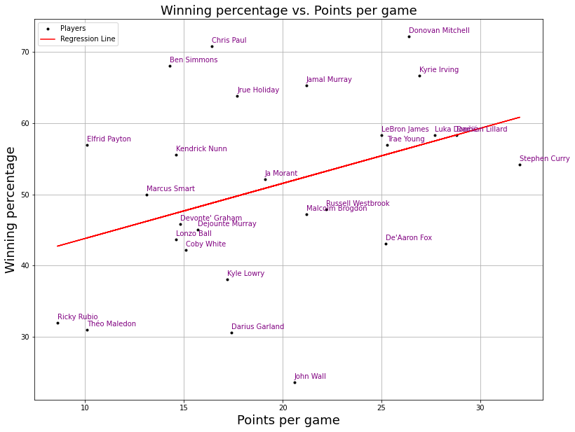

```python
#Getting the values we need, in this case points and win percentage
x = third_table['PTS'].astype(float)
y = third_table['Win%'].astype(float)

plt.figure(figsize=(13,10))
m, b= np.polyfit(x,y, 1)

#Printing out the players on the graph
plt.plot(x, y,'.', color = 'black', label = 'Players')

#Printing out the regression line
plt.plot(x, m*x + b, color = 'red', label = 'Regression Line')
m1 = m
#Changing title, x and y axis of the table - winning
plt.title("Winning percentage vs. Points per game",fontsize=18)
plt.xlabel("Points per game",fontsize=18)
plt.ylabel("Winning percentage",fontsize=18)
plt.legend(loc="upper left")
plt.grid('on')

#Printing out the name of each player for every data on the table
for count, txt in enumerate(third_table['Player']):
        plt.annotate(txt, (x[count], y[count]), textcoords = 'offset points', xytext = (0,5), color = 'purple')

plt.show()
```

**Exploring Assists vs. Winning Percentage**

The point guards job is to run the team's offense by controlling the ball and making sure it gets to the right player at the right time. To identify the importance of the point guard, we are examining the influence of this role on the overall team success by looking at the amount of assists the player averaged. The Winning Percentage vs Assists graph shows, 63 percent of team's whose point guard averaged more than 7 assists per game, won at least 50 percent of their games. Meanwhile, 56 percent of teams whose point guard's averaged less that 7 assists per game, won less than 50 percent of their games.

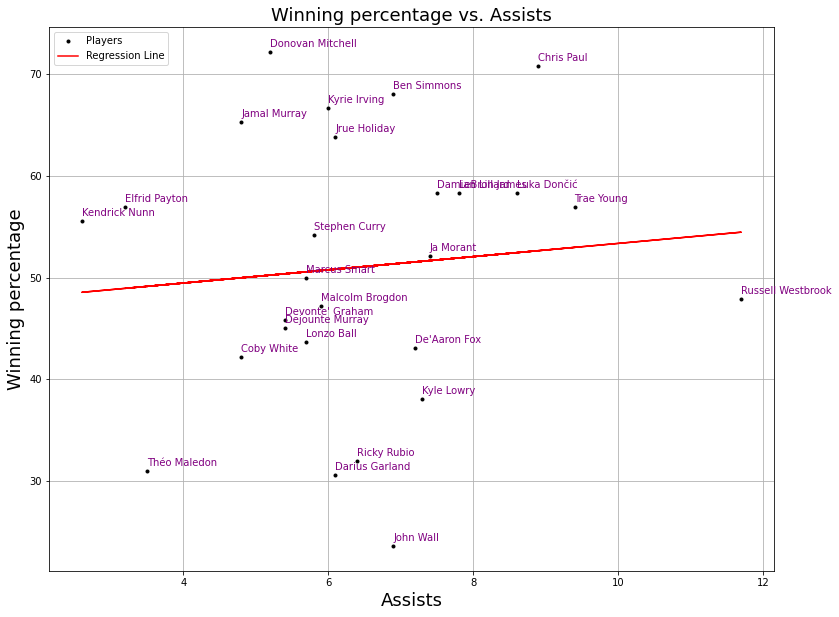

```python
#Graph for assists
#Getting the values we need, in this case assist and win percentage
x = third_table['AST'].astype(float)
y = third_table['Win%'].astype(float)

plt.figure(figsize=(13,10))
m, b= np.polyfit(x,y, 1)
plt.plot(x, y,'.', color = 'black', label = 'Players')
plt.plot(x, m*x + b, color = 'red', label = 'Regression Line')
m2 = m

#Changing title, x and y axis of the table
plt.title("Winning percentage vs. Assists",fontsize=18)
plt.xlabel("Assists",fontsize=18)
plt.ylabel("Winning percentage",fontsize=18)
plt.legend(loc="upper left")
plt.grid('on')


#Printing out the name of each player for every data on the table
for count, txt in enumerate(third_table['Player']):
        plt.annotate(txt, (x[count], y[count]), textcoords = 'offset points', xytext = (0,5), color = 'purple')

plt.show()
```

**Exploring Rebounds vs. Winning Percentage**

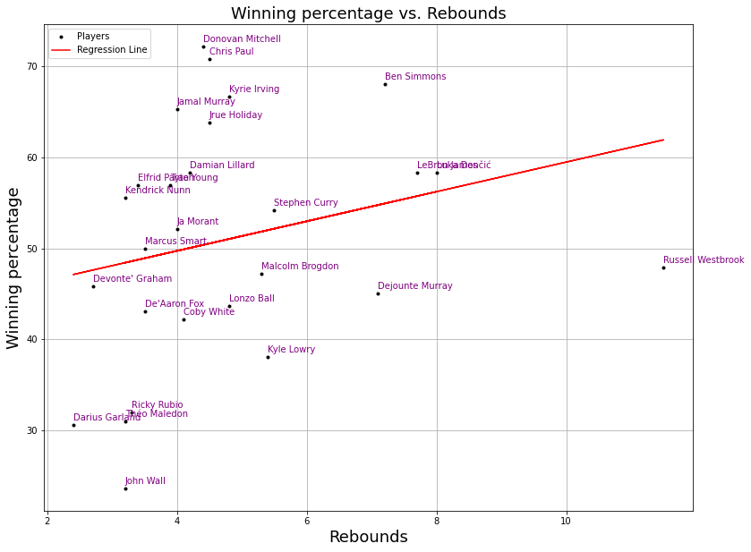

```python
#Getting the values we need, in this case rebounds and win percentage
x = third_table['TRB'].astype(float)
y = third_table['Win%'].astype(float)

plt.figure(figsize=(13,10))
m, b= np.polyfit(x,y, 1)
plt.plot(x, y,'.', color = 'black', label = 'Players')
plt.plot(x, m*x + b, color = 'red', label = 'Regression Line')
m3 = m

#Changing title, x and y axis of the table
plt.title("Winning percentage vs. Rebounds",fontsize=18)
plt.xlabel("Rebounds",fontsize=18)
plt.ylabel("Winning percentage",fontsize=18)
plt.legend(loc="upper left")
plt.grid('on')


#Printing out the name of each player for every data on the table
for count, txt in enumerate(third_table['Player']):
        plt.annotate(txt, (x[count], y[count]), textcoords = 'offset points', xytext = (0,5), color = 'purple')

plt.show()
```

**Exploring Turnovers vs. Winning Percentage**

Our next graph examines the effort of point guards to protect the ball and how turnovers impact the team's ability to win. 63% of teams whose point guards averaged more than 3 turnovers won at least 50% of their games. The data is showing that a point guards's loss of possesions is not having a major impact on the team's succes. When a point guards averaged less than 3 turnovers, only 50% of teams won at least 50% of their games.

The data shows a slight trend that team's with point guards who turnover the ball more are winning more games. This raises the question why? Since turnovers are considered negative plays for the team, why are teams winning more when a point guard average more turnovers. One assumption we can make based on the data is that point guards are insignificant so their lack of success does not impact the overall team. Although another assumption we could make, one that we believe is true, is that point guards who turn the ball over more, possess the ball more. Therefore if a point guard often is in possession of the ball and frequently attempting to find oppurtunites to pass the ball, they are more likely to turn the ball over.

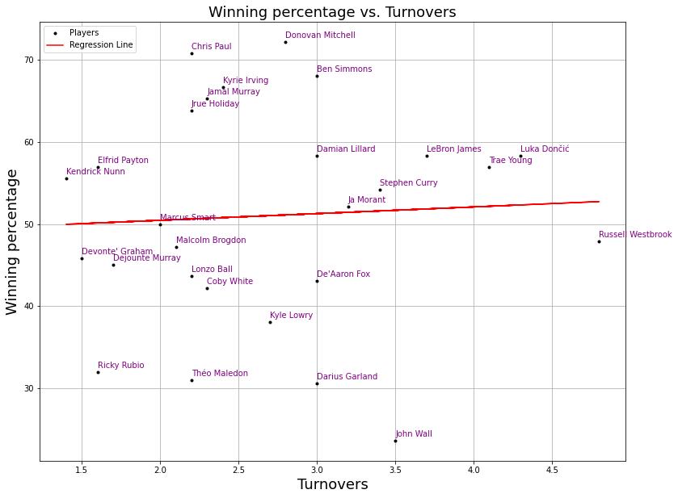

```python
#Graph for turnovers
#Getting the values we need, in this case turnovers and win percentage
x = third_table['TOV'].astype(float)
y = third_table['Win%'].astype(float)

plt.figure(figsize=(13,10))
m, b= np.polyfit(x,y, 1)
plt.plot(x, y,'.', color = 'black', label = 'Players')
plt.plot(x, m*x + b, color = 'red', label = 'Regression Line')
m3 = m

#Changing title, x and y axis of the table
plt.title("Winning percentage vs. Turnovers",fontsize=18)
plt.xlabel("Turnovers",fontsize=18)
plt.ylabel("Winning percentage",fontsize=18)
plt.legend(loc="upper left")
plt.grid('on')


#Printing out the name of each player for every data on the table
for count, txt in enumerate(third_table['Player']):
        plt.annotate(txt, (x[count], y[count]), textcoords = 'offset points', xytext = (0,5), color = 'purple')

plt.show()
```

**Exploring Defensive Stat vs. Winning Percentage**

To determine how well a point guard defends their opponent, we decided to combine their average blocks and steals for the season to create the defensive stat. 53% of teams whose point guard have a rating greater than 1.5, won at least 50% of their games. 53% of teams whose point guards have a rating less than 1.5, won 50% of their games. This stat indicates that point guards are not expected to prioritize defense and teams do not depend on them for defense.

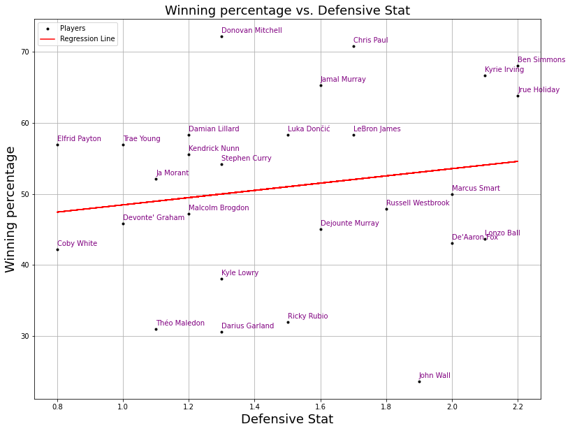

```python
#Getting defensive stats for players
defensive_score = (third_table['BLK'].astype(float) +  third_table['STL'].astype(float))

#Getting the values we need, in this case defensive stats and win percentage
x = defensive_score.astype(float)
y = third_table['Win%'].astype(float)

plt.figure(figsize=(13,10))
m, b= np.polyfit(x,y, 1)
plt.plot(x, y,'.', color = 'black', label = 'Players')
plt.plot(x, m*x + b, color = 'red', label = 'Regression Line')
m5 = m

#Changing title, x and y axis of the table
plt.title("Winning percentage vs. Defensive Stat",fontsize=18)
plt.xlabel("Defensive Stat",fontsize=18)
plt.ylabel("Winning percentage",fontsize=18)
plt.legend(loc="upper left")
plt.grid('on')


#Printing out the name of each player for every data on the table
for count, txt in enumerate(third_table['Player']):
        plt.annotate(txt, (x[count], y[count]), textcoords = 'offset points', xytext = (0,5), color = 'purple')

plt.show()
```

**Exploring 2-Point Percentage vs. Winning Percentage**

Next, we are analyzing the 2 point shooting percentage to determine its effect on the team's success. Based on the data 90% of teams, whose point guard made at least 50 percent of their 2 point shots, won at least 50% of their games. 25% of teams, whose point guard made less than 50% of their shots, won at least 50% of their games. It is apparent that winning teams have point guard who can make the 2 point shots more times than not. One of the things that we noticed was effiency. If the players were more efficient in shooting, there seemed to be a trend in the winning percentage.

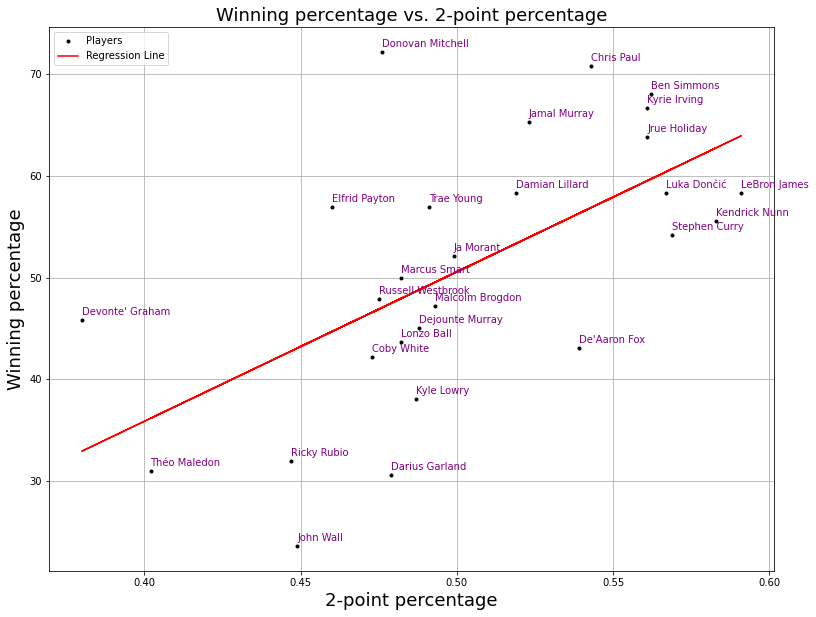

```python
#Getting the values we need, in this case 2 point percentage and win percentage
x = third_table['2P%'].astype(float)
y = third_table['Win%'].astype(float)

plt.figure(figsize=(13,10))
m, b= np.polyfit(x,y, 1)
plt.plot(x, y,'.', color = 'black', label = 'Players')
plt.plot(x, m*x + b, color = 'red', label = 'Regression Line')
m4 = m

#Changing title, x and y axis of the table
plt.title("Winning percentage vs. 2-point percentage",fontsize=18)
plt.xlabel("2-point percentage",fontsize=18)
plt.ylabel("Winning percentage",fontsize=18)
plt.legend(loc="upper left")
plt.grid('on')


#Printing out the name of each player for every data on the table
for count, txt in enumerate(third_table['Player']):
        plt.annotate(txt, (x[count], y[count]), textcoords = 'offset points', xytext = (0,5), color = 'purple')

plt.show()
```

**Exploring 3-Point Percentage vs. Winning Percentage**

For more information about the transition of the sport of basketball and the newly found importance/value in the 3 point shot take a look here:

https://www.nba.com/news/3-point-era-nba-75

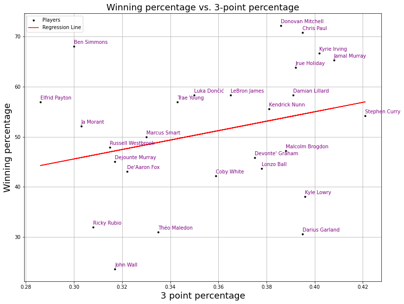

```python
#Getting the values we need, in this case 3 point percentage and win percentage
x = third_table['3P%'].astype(float)
y = third_table['Win%'].astype(float)

plt.figure(figsize=(13,10))
m, b= np.polyfit(x,y, 1)
plt.plot(x, y,'.', color = 'black', label = 'Players')
plt.plot(x, m*x + b, color = 'red', label = 'Regression Line')
m4 = m

#Changing title, x and y axis of the table
plt.title("Winning percentage vs. 3-point percentage",fontsize=18)
plt.xlabel("3 point percentage",fontsize=18)
plt.ylabel("Winning percentage",fontsize=18)
plt.legend(loc="upper left")
plt.grid('on')

#Printing out the name of each player for every data on the table
for count, txt in enumerate(third_table['Player']):
        plt.annotate(txt, (x[count], y[count]), textcoords = 'offset points', xytext = (0,5), color = 'purple')

plt.show()
```

**Exploring Effective Field Goal vs. Winning Percentage**

After looking at the past two graphs, we can see that efficiency in shooting is highly valued by the point guard position. Effective field goal percentage is a statistic that represents the total percentage of all shots taken and takes into the account whether a shot attempted was worth 2 or 3 points. 90% of teams, whose point guard made at least 54% of shots from the field, won more than 50% of their games. Once again highlighting that efficiency is a skill by point guards that leads to winning. Of all the skills we've looked at, a point guard with a high effective field goal percentage seems to have the highest correlation with the respective team's winning percentage based off these graphs. We will return to this ability of scoring efficiently later on when we begin to compare our two data sets of point guards from two different eras.

For more information about effective field goal percentage, the importance of it in basketball and the math behind it take a look at this link:

https://www.breakthroughbasketball.com/stats/effective-field-goal-percentage.html

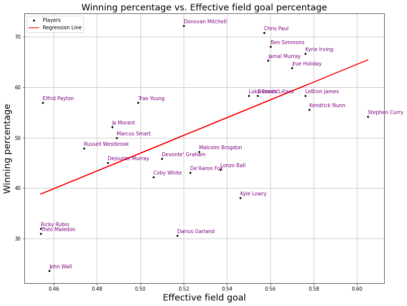

```python
#Getting the values we need, in this case effective field goal and win percentage
x = third_table['eFG%'].astype(float)
y = third_table['Win%'].astype(float)

plt.figure(figsize=(13,10))
m, b= np.polyfit(x,y, 1)
plt.plot(x, y,'.', color = 'black', label = 'Players')
plt.plot(x, m*x + b, color = 'red', label = 'Regression Line')
m6 = m

#Changing title, x and y axis of the table
plt.title("Winning percentage vs. Effective field goal percentage",fontsize=18)
plt.xlabel("Effective field goal",fontsize=18)
plt.ylabel("Winning percentage",fontsize=18)
plt.legend(loc="upper left")
plt.grid('on')


#Printing out the name of each player for every data on the table
for count, txt in enumerate(third_table['Player']):
        plt.annotate(txt, (x[count], y[count]), textcoords = 'offset points', xytext = (0,5), color = 'purple')

plt.show()
```

**Exploring Free throw Percentage vs. Winning Percentage**

Point guards are expected to be good free throw shooters. Close games are often decided by free throws. With that being said we are looking at how a point guards ability to make free throws effects the success of the team. Based on the data, 57% of teams, whose point guards made 80% of free throws, won at least 50% of their games. Only 46% of teams whose point guards made less than 80% of free throws, won at least 50% of their games.

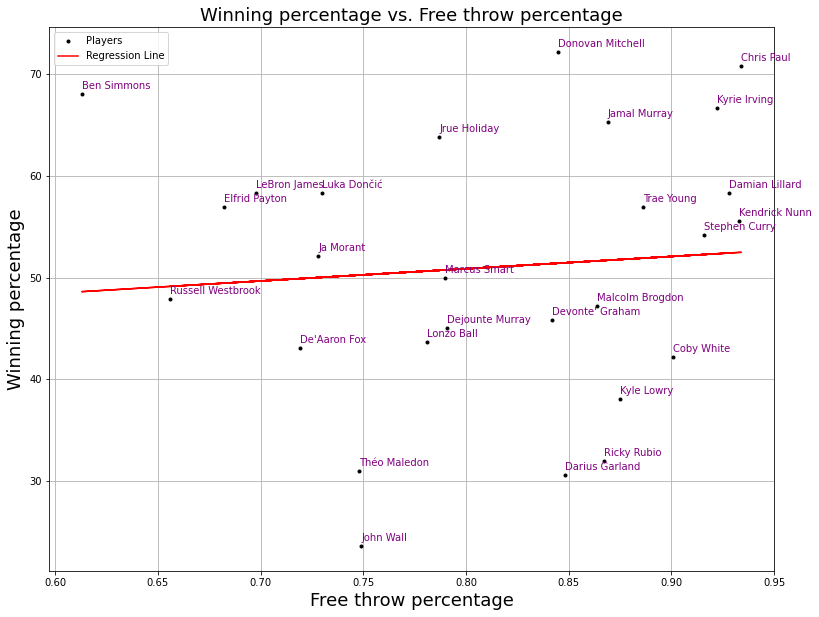

```python
#Getting the values we need, in this case Free throw percentage and win percentage
x = third_table['FT%'].astype(float)
y = third_table['Win%'].astype(float)

plt.figure(figsize=(13,10))
m, b= np.polyfit(x,y, 1)
plt.plot(x, y,'.', color = 'black', label = 'Players')
plt.plot(x, m*x + b, color = 'red', label = 'Regression Line')
m8 = m

#Changing title, x and y axis of the table
plt.title("Winning percentage vs. Free throw percentage",fontsize=18)
plt.xlabel("Free throw percentage",fontsize=18)
plt.ylabel("Winning percentage",fontsize=18)
plt.legend(loc="upper left")
plt.grid('on')


#Printing out the name of each player for every data on the table
for count, txt in enumerate(third_table['Player']):
        plt.annotate(txt, (x[count], y[count]), textcoords = 'offset points', xytext = (0,5), color = 'purple')

plt.show()
```

**Exploring Age vs. Winning Percentage**

Our group was curious to see if age made an impact on the performance by the players and their respective teams. Usually, as atheletes get older, they get effected.

Age vs Winning Percentage examines which age group is winning the most. The age range 18-23, is around the time players get drafted. Being new to the NBA they are not expected to be best. Research shows, NBA players peak around age 27. Based on the boxplot, players within the age group of 24-28, are winning more than any other age group.

Henson, M. (2019, November 26). The exact age that NBA players are in their prime. Sportscasting. Retrieved December 17, 2021, from https://www.sportscasting.com/the-exact-age-that-nba-players-are-in-their-prime/

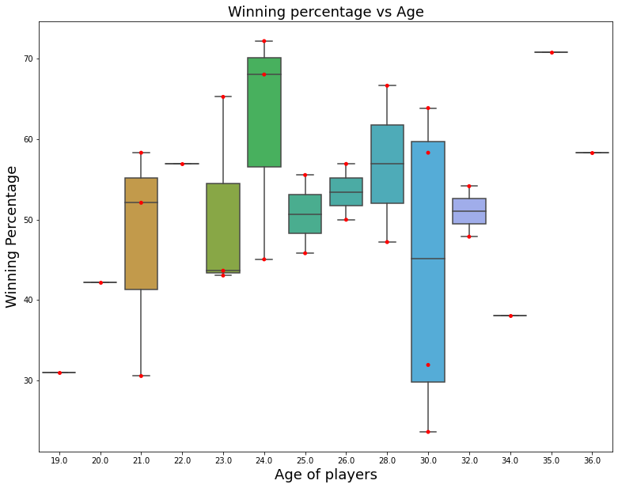

```python
#Getting the age and winning percentage
x = third_table['Age'].astype(float)
y = third_table['Win%'].astype(float)

plt.figure(figsize=(13,10))
#Plotting the boxplot
ax = sns.boxplot(x,y)
#Players at exact ages
ax = sns.swarmplot(x=x, y= y, data=third_table, color= 'red')


#Changing some things about the plot
plt.ylabel("Winning Percentage",fontsize=18)
plt.xlabel("Age of players",fontsize=18)
plt.title("Winning percentage vs Age",fontsize=18)
plt.show()
```

**Exploring Point Guard Performance Scores to Winning Rates (2020 - 2021)**

Now that we have looked at the various skills of the point guard and the impact it has on winning. We will now give each qualifed player a total score based off their performance in points, assists, rebounds, defensive ability, EFG% and FT%. We will look at the averages for each stat for all 6 skills and see how each player performed according to the average of the rest of the players. A player with a higher score will have performed above average in more stats. We will then look at each player's given score and compare that to their team's winning percentage to see whether a point guard's performance correlates with how well a team performs or whether a point guard performance is not as valued as one might assume.

The graph below compares each point guard's recieved score with their respective team's winning percentage in the year 2020-2021. After looking at the data we can see that point guard who averaged higher scores tend to mean their team had a higher winning percentage. This is highlighted when we look at the 11 highest scored players from Trae Young to Russell Westbrook who all tend to have higher winning percentages than the rest. An outlier in this data would be Donovan Mitchell who has the highest winning percentage but stands in the very middle for score. Perhaps a coincidence, but the team he plays for, the Utah Jazz, were one of the two teams that had two point guards that started 40+ games. Perhaps meaning that two point guards that played exceptionally well is even more valued than just one, while also highlighting the value in the point guard position.

```python
#Converting to float so we can use the needed variables
third_table['PTS'] = third_table['PTS'].astype(float)
third_table['AST'] = third_table['AST'].astype(float)
third_table['TRB'] = third_table['TRB'].astype(float)
third_table['DFS'] = third_table['STL'].astype(float) + third_table['BLK'].astype(float)
third_table['eFG%'] = third_table['eFG%'].astype(float)
third_table['FT%'] = third_table['FT%'].astype(float)
third_table['score'] = 0

#Figuring out the the score with points
for i in range(len(third_table)):
  third_table.loc[i, 'score'] = (third_table.loc[i,'PTS']/third_table['PTS'].mean())  + (third_table.loc[i,'AST']/third_table['AST'].mean()) + (third_table.loc[i,'TRB']/third_table['TRB'].mean()) + (third_table.loc[i,'DFS']/third_table['DFS'].mean()) + (third_table.loc[i,'eFG%']/third_table['eFG%'].mean()) + (third_table.loc[i,'FT%']/third_table['FT%'].mean())
```

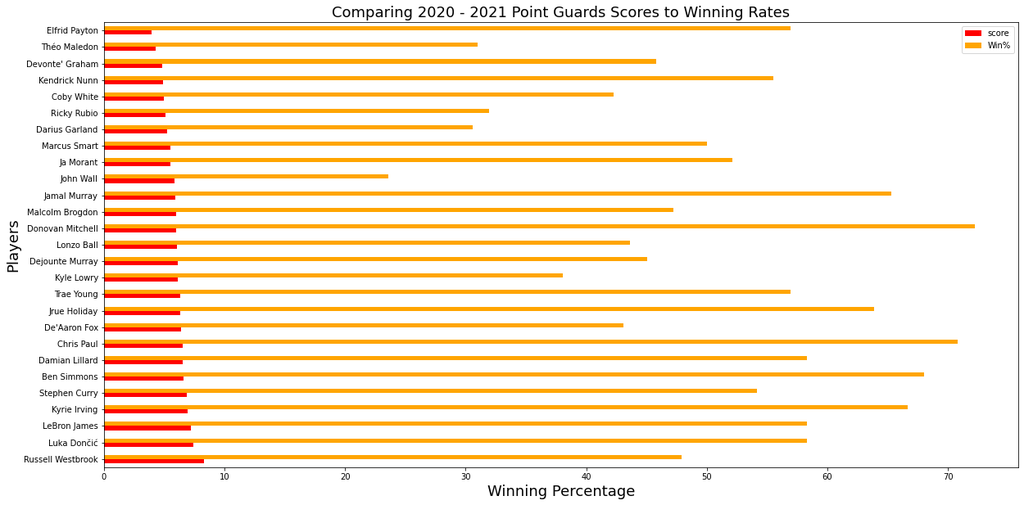

```python
#Calculating the scores for the 2020-2021 point guards
third_table.sort_values('score', ascending=False).plot.barh(x='Player', y=['score','Win%'], color = ['red','orange'], figsize = (20,10))

#Changing some options about the graph
plt.title("Comparing 2020 - 2021 Point Guards Scores to Winning Rates",fontsize=18)
plt.xlabel("Winning Percentage",fontsize=18)
plt.ylabel("Players",fontsize=18)
```

**Exploring eFG% in 2020-2021**

The following graph specifcally focuses on what we believe is the most important trait of the point guard in today's game, efficient scoring/shooting, which is measured by their effective field goal percentage. After looking at this graph we can see that the most efficient scorers tend to lead their teams in winning percentage, as we saw from before when looking at the regression lines. This tells us that highly efficient point guards that score the basketball for their team, usually results in the team winning that game and having a successful season overall.

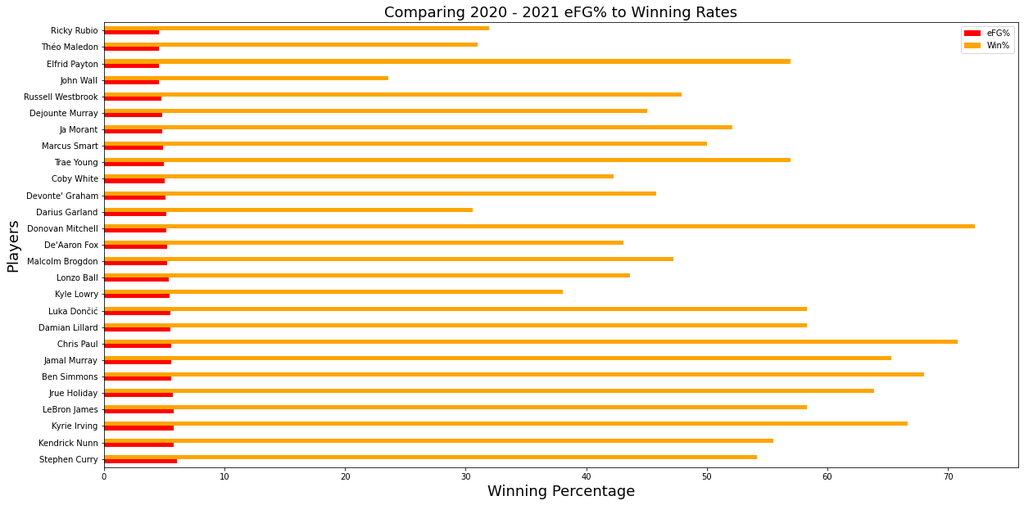

```python
#Multiplying the eFG% value to be able to analyze it. Numbers were too small to be analyzed.
third_table['eFG%'] = third_table['eFG%']*10
third_table.sort_values('eFG%', ascending=False).plot.barh(x='Player', y=['eFG%','Win%'], color = ['red','orange'], figsize = (20,10))

#Changing some options about the graph
plt.title("Comparing 2020 - 2021 eFG% to Winning Rates",fontsize=18)
plt.xlabel("Winning Percentage",fontsize=18)
plt.ylabel("Players",fontsize=18)
```

**Exploring Point Guard Performance Scores to Winning Rates (1999 - 2000)**

The next graph is the same as above, except we are now looking at the qualifying point guards from the 1999 - 2000 NBA season. We decided to choose this year to compare it to the current era of basketball and see if the values and value of the point guard position has changed since. After looking at the data, we can see that the data has almost been completely flipped from the previous graph. Where the point guards that had the lowest scores, tended to be apart of the team's with the highest winning percentages, specifically from Avery Johnson to Eric Snow, all of which scored lower than the average. One outlier that stands out in this data is John Stockton, a hall of fame point guard, that is considered a traditional point guard that focused on playmaking and setting his teammates up rather than scoring.

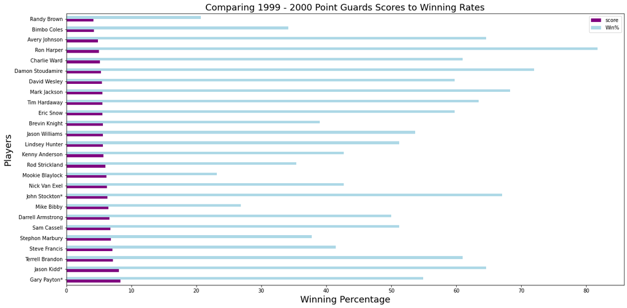

```python
#Calculating the scores for the 1999-2000 point guards
retro_table['score'] = 0
for i in range(len(retro_table)):
  #Plotting the score and the win %
  retro_table.loc[i, 'score'] = (retro_table.loc[i,'PTS']/retro_table['PTS'].mean())  + (retro_table.loc[i,'AST']/retro_table['AST'].mean()) + (retro_table.loc[i,'TRB']/retro_table['TRB'].mean()) + (retro_table.loc[i,'DFS']/retro_table['DFS'].mean()) + (retro_table.loc[i,'eFG%']/retro_table['eFG%'].mean()) + (retro_table.loc[i,'FT%']/retro_table['FT%'].mean())
retro_table.sort_values('score', ascending=False).plot.barh(x='Player', y=['score','Win%'], color = ['purple','lightblue'], figsize = (20,10))

#Changing some options about the plots
plt.title("Comparing 1999 - 2000 Point Guards Scores to Winning Rates",fontsize=18)
plt.xlabel("Winning Percentage",fontsize=18)
plt.ylabel("Players",fontsize=18)
```

**Exploring eFG% in 1999-2000**

When we compared the 1999-2000 eFG% to the 2020-2021 we noticed one major difference. When point guards have a better rate in eFG%, there is no trend in teams doing better in 1999-2000. In the 1999-2000 data set, there was a mix set of data where some players had a high eFG% but did not effect the performance of the team. However, this was a visible trend that was shown in the 2020-2021 data set. We believe this tells us that efficient scoring by the point guard wasn't as valued during this period as it is now.

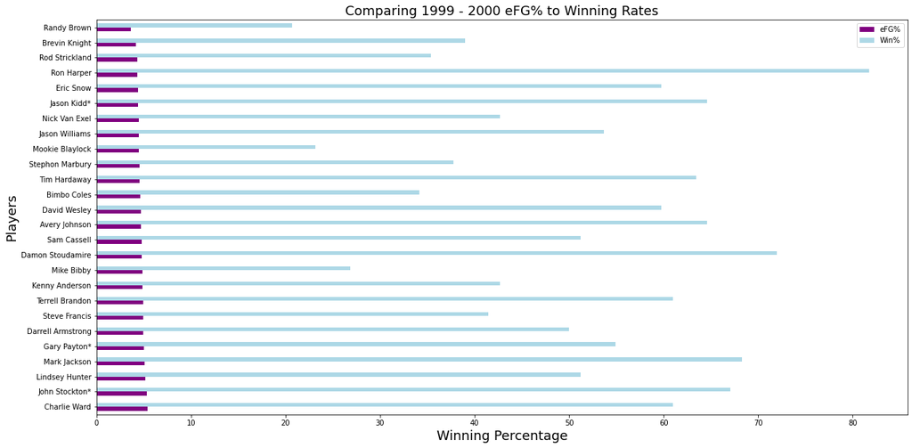

```python
#Multiplying the eFG% value to be able to analyze it. Numbers were too small to be analyzed.
retro_table['eFG%'] = retro_table['eFG%']*10
retro_table.sort_values('eFG%', ascending=False).plot.barh(x='Player', y=['eFG%','Win%'], color = ['purple','lightblue'], figsize = (20,10))

#Changing some options about the plots
plt.title("Comparing 1999 - 2000 eFG% to Winning Rates",fontsize=18)
plt.xlabel("Winning Percentage",fontsize=18)
plt.ylabel("Players",fontsize=18)
```

**Conclusion**

Now that all of the data has been analyzed, we will now form a conclusion from what we have learned and decide if our original hypothesis holds true. After visualizing the two data sets and comparing them we have come to the conclusion that the point guard position is much more valued in today's game and valued in a much different way than in the past which confirms our original hypothesis.

This can be seen by looking at the last few graphs we saw, which showed that NBA teams in today's game depend on a point guard that can perform well and in particular score the basketball efficiently and effectively. On the contrary, we also saw that point guards 20 years ago were valued much less, and that a point guard that performed well did not mean that the respective team had success in winning. And even more it seemed as though that most teams that performed well back then had point guards that were less involved and had lower scores overall rather than more involved with higher scores.

As the sport of basketball continues to evolve and grow it seems as though the traditional idea and purpose of a point guard is beginning to change. So long are the days where a point guard only job is to assist the basketball and get the ball to the team's best player. The point guard position in today's game is much more valued as a scorer of the basketball that can efficiently score and lead the team's offense. In the near future, we believe this trend will only keep continuing and that offense, the three point shot and scoring in general will only be valued more and more as time goes on. And that the players and point guards who are the best at these skills will be the more valued than ever.

```python
#Converting the file to HTML
#!jupyter nbconvert --to html AnalyzingPointGuards.ipynb
```